# USA: Harmful Weather Events

## Synopsis

Analysis of Storm Data from the U.S. National Oceanic and Atmospheric Administration to answer the following questions:

1. Across the United States, which types of events are most harmful with respect to population health?
2. Across the United States, which types of events have the greatest economic consequences?

## Requirements

The *stringdist* package is required.

```r
library(stringdist)
```

## Data Processing

Load data from the NOAA Storm Database, available from https://d396qusza40orc.cloudfront.net/repdata%2Fdata%2FStormData.csv.bz2.

```r
# Load Data from file
if(!exists("src_data")){
    data_file = "data/repdata_data_StormData.csv"
    src_data <- read.csv(data_file, stringsAsFactors = FALSE)
}

# Subset to save memory
# src_data <- subset(src_data[190000:200000,c(2, 8, 23, 24, 25, 26,27, 28)], CROPDMG > 0)
src_data <- subset(src_data[,c(2, 8, 23, 24, 25, 26,27, 28)], CROPDMG > 0)
```

To calculate the most costly events the event type (EVTYPE) field needs to be cleaned up and mapped to the clean list of events defined in *National Weather Service Instruction 10-1605*.

This is done by comparing the EVTYPE value with the events listed and choosing the closest match.

| Astronomical Low Tide | Frost/Freeze | Marine High Wind | Wildfire |
| --- | --- | --- | --- |
| Avalanche | Funnel Cloud | Marine Strong Wind | Winter Storm |
| Blizzard | Freezing Fog | Marine Thunderstorm Wind | Winter Weather |
| Coastal Flood | Hail | Rip Current |  |
| Cold/Wind Chill | Heat | Seiche |  |
| Debris Flow | Heavy Rain | Sleet |  |
| Dense Fog | Heavy Snow | Storm Surge/Tide |  |
| Dense Smoke | High Surf | Strong Wind |  |
| Drought | High Wind | Thunderstorm Wind |  |
| Dust Devil | Hurricane (Typhoon) | Tornado |  |
| Dust Storm | Ice Storm | Tropical Depression |  |
| Excessive Heat | Lake-Effect Snow | Tropical Storm |  |
| Extreme Cold/Wind Chill | Lakeshore Flood | Tsunami |  |
| Flash Flood | Lightning | Volcanic Ash |  |
| Flood | Marine Hail | Waterspout |  |

The PROPDMGEXP and CROPDMGEXP fields are also cleaned up to provide consistent multipliers.

```r
# List of Events
events=c("Astronomical Low Tide","Avalanche","Blizzard","Coastal Flood","Cold/Wind Chill","Debris Flow","Dense Fog","Dense Smoke","Drought","Dust Devil","Dust Storm","Excessive Heat","Extreme Cold/Wind Chill","Flash Flood","Flood","Frost/Freeze","Funnel Cloud","Freezing Fog","Hail","Heat","Heavy Rain","Heavy Snow","High Surf","High Wind","Hurricane (Typhoon)","Ice Storm","Lake-Effect Snow","Lakeshore Flood","Lightning","Marine Hail","Marine High Wind","Marine Strong Wind","Marine Thunderstorm Wind","Rip Current","Seiche","Sleet","Storm Surge/Tide","Strong Wind","Thunderstorm Wind","Tornado","Tropical Depression","Tropical Storm","Tsunami","Volcanic Ash","Waterspout","Wildfire","Winter Storm","Winter Weather")

for(i in 1:nrow(src_data)){

    # Map Event Types (EVTYPE) to the nearest event from list above.
    src_data$event[i] <- events[amatch(src_data$EVTYPE[i], events, maxDist=Inf)]

    # Clean up Prop Damage Multipliers
    if(src_data$PROPDMGEXP[i] %in% c("", "-", "?")) {src_data$PROPDMGEXP[i] = "Z"}
    else if (src_data$PROPDMGEXP[i] %in% c(0:8)){src_data$PROPDMGEXP[i] = "T"}
    else if(src_data$PROPDMGEXP[i] == "+"){src_data$PROPDMGEXP[i] = "O"}
    else {src_data$PROPDMGEXP[i] = toupper(src_data$PROPDMGEXP[i])}

    # Clean up Crop Damage Multipliers
    if(src_data$CROPDMGEXP[i] %in% c("", "-", "?")) {src_data$CROPDMGEXP[i] = "Z"}
    else if (src_data$CROPDMGEXP[i] %in% c(0:8)){src_data$CROPDMGEXP[i] = "T"}
    else if(src_data$CROPDMGEXP[i] == "+"){src_data$CROPDMGEXP[i] = "O"}
    else {src_data$CROPDMGEXP[i] = toupper(src_data$CROPDMGEXP[i])}
}
```

Now the impact of each weather event can be calculated. The health impact has been calculated as the sum of the number of injuries plus the number of fatalities.

```r
# Calculate Impact on Population Health
src_data$health_impact = src_data$FATALITIES + src_data$INJURIES

# Calculate Impact on Property
multipliers = c("Z"=0, "O"=1, "T"=10, "H" = 100, "K"=100, "M"=1000000, "B"=1000000000)
src_data$property_impact = src_data$PROPDMG*multipliers[as.character(src_data$PROPDMGEXP)]
src_data$crop_impact = src_data$CROPDMG*multipliers[src_data$CROPDMGEXP]
```

## Results

The health, property and crop impact is calculated as a total per event. The top 5 events are summarised and displayed below.

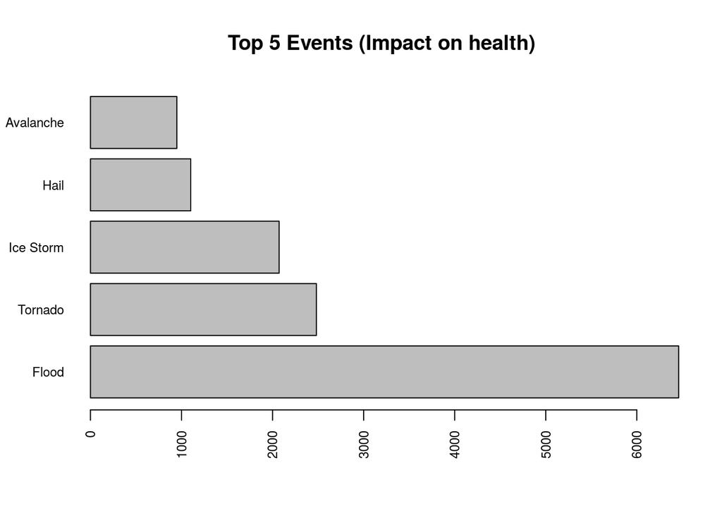

```r
data_summ <- aggregate(cbind(health_impact, property_impact, crop_impact) ~ event, data = src_data, FUN = sum)

health <- data_summ[, 1:2]
health <- health[order(-health$health_impact),]
health <- health[1:5,]
barplot(health$health_impact, names.arg = health$event, main="Top 5 Events (Impact on health)", horiz=TRUE, las="2", cex.names="0.75", cex.axis="0.75")
```

```r
health
```

```
##        event health_impact
## 15     Flood          6460
## 32   Tornado          2481
## 23 Ice Storm          2072
## 18      Hail          1101
## 2  Avalanche           949
```

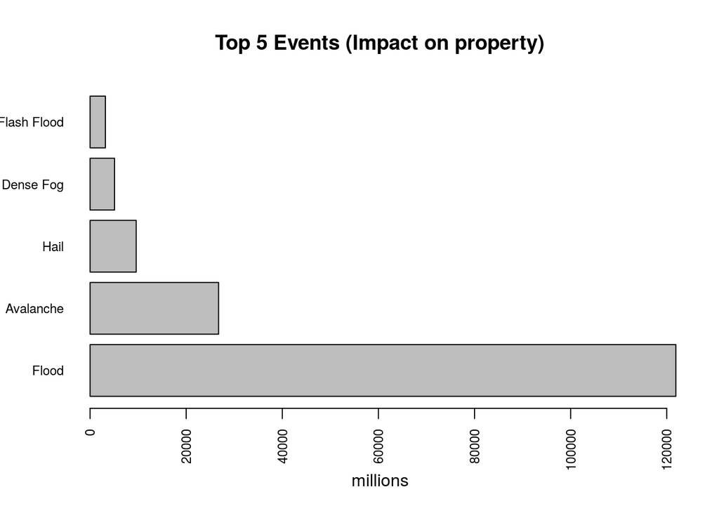

```r
property <- data_summ[, c(1,3)]
property <- property[order(-property$property_impact),]
property <- property[1:5,]
property$property_impact <- property$property_impact/1000000
barplot(property$property_impact, names.arg = property$event, main="Top 5 Events (Impact on property)", horiz=TRUE, xlab="millions", las="2", cex.names="0.75", cex.axis="0.75")
```

```r
property
```

```
##          event property_impact
## 15       Flood      121896.783
## 2    Avalanche       26738.913
## 18        Hail        9598.163
## 7    Dense Fog        5083.759
## 14 Flash Flood        3182.517
```

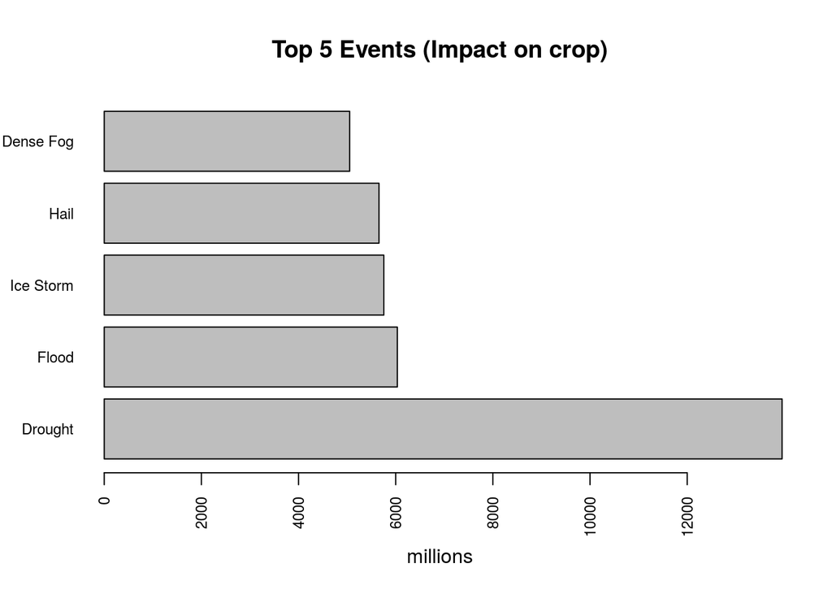

```r
crop <- data_summ[, c(1,4)]
crop <- crop[order(-crop$crop_impact),]
crop <- crop[1:5,]
crop$crop_impact <- crop$crop_impact/1000000
barplot(crop$crop_impact, names.arg = crop$event, main="Top 5 Events (Impact on crop)", horiz=TRUE, xlab="millions", las="2", cex.names="0.75", cex.axis="0.75")
```

```r
crop
```

```
##        event crop_impact
## 9    Drought   13953.265
## 15     Flood    6032.896
## 23 Ice Storm    5755.551
## 18      Hail    5656.054
## 7  Dense Fog    5051.706
```